# Rolling with the Molecules: Cannabis Chemistry in Motion

Franklin Johnson via yourweeddata.com

Packages for this pipeline were loaded using source(“install_packages_if_missing.R”)

Now, just load the data:

```r
lab_data <- read_csv("lab_data.csv", show_col_types = FALSE)

glimpse(lab_data)
```

```
## Rows: 139,550
## Columns: 19
## $ sale_date_month             <date> 2024-09-01, 2025-02-01, 2025-02-01, 2025-…
## $ licensee_id                 <dbl> 1492, 969, 1978, 2328, 3145, 992, 3140, 53…
## $ product_name                <chr> "Bulk Batch - lil Ray's Strawberry Lemonad…
## $ inventory_type_sub_category <chr> "Liquid Edibles", "Infused Mixes", "Infuse…
## $ retail_sales_amt            <dbl> 176.16, 14.30, 3.61, 204.16, 102.80, 57.54…
## $ potency_cbc_perc_avg        <dbl> 0, 0, 0, 0, 0, 0, 0, 0, 0, 0, 0, 0, 0, 0, …
## $ potency_cbd_perc_avg        <dbl> 0.00, 0.33, 0.36, 0.00, 0.22, 1.10, 0.00, …
## $ potency_cbda_perc_avg       <dbl> 0.00, 0.00, 0.30, 0.00, 0.00, 1.70, 0.00, …
## $ potency_cbdv_perc_avg       <dbl> 0, 0, 0, 0, 0, 0, 0, 0, 0, 0, 0, 0, 0, 0, …
## $ potency_cbg_perc_avg        <dbl> 0, 0, 0, 0, 0, 0, 0, 0, 0, 0, 0, 0, 0, 0, …
## $ potency_cbga_perc_avg       <dbl> 0, 0, 0, 0, 0, 0, 0, 0, 0, 0, 0, 0, 0, 0, …
## $ potency_cbn_perc_avg        <dbl> 0, 0, 0, 0, 0, 0, 0, 0, 0, 0, 0, 0, 0, 0, …
## $ potency_d8thc_perc_avg      <dbl> 0, 0, 0, 0, 0, 0, 0, 0, 0, 0, 0, 0, 0, 0, …
## $ potency_d9thc_perc_avg      <dbl> 0.00, 0.00, 9.30, 0.00, 0.22, 19.00, 0.16,…
## $ potency_d9thca_perc_avg     <dbl> 0.0, 20.0, 20.0, 0.0, 0.0, 14.0, 0.0, 0.0,…
## $ potency_thca_perc_avg       <dbl> 0, 0, 0, 0, 0, 0, 0, 0, 0, 0, 0, 0, 0, 0, …
## $ potency_thcv_perc_avg       <dbl> 0, 0, 0, 0, 0, 0, 0, 0, 0, 0, 0, 0, 0, 0, …
## $ potency_total_cbd_perc_avg  <dbl> 0.00, 0.33, 0.62, 0.00, 0.22, 2.60, 0.00, …
## $ potency_total_thc_perc_avg  <dbl> 0.00, 20.00, 27.00, 0.00, 0.22, 31.00, 0.1…
```

We’ll align our modeling around these relationships — ideally by plotting pathways by product, by category, or even over time.

EDA - Top subcategories by record count

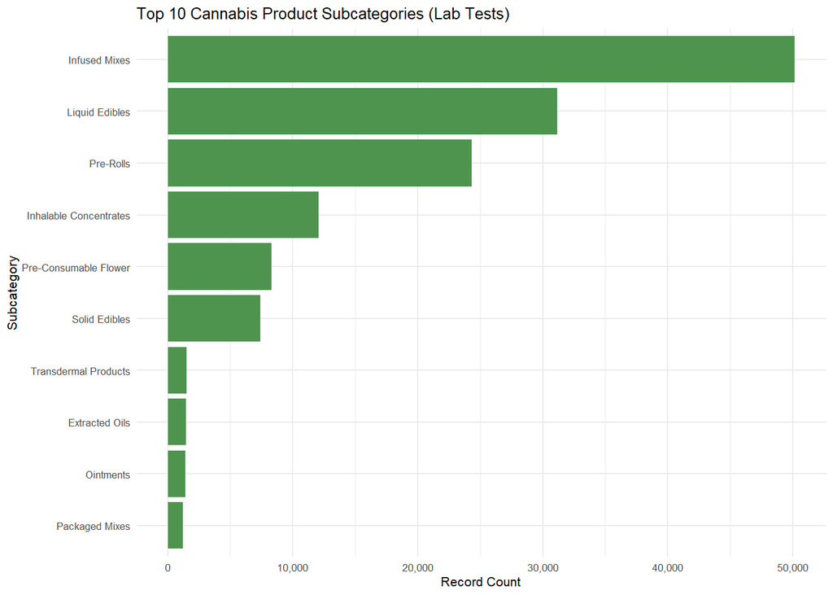

```r
lab_data %>%
  count(inventory_type_sub_category, sort = TRUE) %>%
  slice_head(n = 10) %>%
  ggplot(aes(x = reorder(inventory_type_sub_category, n), y = n)) +
  geom_col(fill = "#4E944F") +
  scale_y_continuous(labels = comma_format()) +
  coord_flip() +
  labs(
    title = "Top 10 Cannabis Product Subcategories (Lab Tests)",
    x = "Subcategory", y = "Record Count"
  ) +
  theme_minimal(base_size = 8)
```

Understanding Cannabinoid Biosynthesis Logic

🌿 Cannabinoid Biosynthesis Pathway

| Pathway Stage | Source Compound | Resulting Product | Conversion Process |
| --- | --- | --- | --- |
| Primary Precursor | CBGA | THCA, CBDA, CBCA | Synthase enzymes |
| Decarboxylation | THCA, CBDA, CBCA | Δ9-THC, CBD, CBC | Heat, UV, or time |
| Degradation | Δ9-THC | CBN, Δ8-THC | Oxidation / Isomerization |

Pathway Building Logic

```r
# Group by subcategory or product name to observe average transitions
biosynthesis_summary <- lab_data %>%
  group_by(inventory_type_sub_category) %>%
  summarise(
    cbga = mean(potency_cbga_perc_avg, na.rm = TRUE),
    thca = mean(potency_thca_perc_avg, na.rm = TRUE),
    d9thc = mean(potency_d9thc_perc_avg, na.rm = TRUE),
    d9thca = mean(potency_d9thca_perc_avg, na.rm = TRUE),
    cbda = mean(potency_cbda_perc_avg, na.rm = TRUE),
    cbd = mean(potency_cbd_perc_avg, na.rm = TRUE),
    cbn  = mean(potency_cbn_perc_avg, na.rm = TRUE),
    .groups = "drop"
  )

kable(biosynthesis_summary)
```

| inventory_type_sub_category | cbga | thca | d9thc | d9thca | cbda | cbd | cbn |
| --- | --- | --- | --- | --- | --- | --- | --- |
| Consumable Flower | 0 | 0 | 2.0598431 | 49.3578039 | 0.0133725 | 0.0959608 | 0 |
| Extracted Oils | 0 | 0 | 22.0737087 | 50.0977141 | 0.3757384 | 2.8862374 | 0 |
| Infused Mixes | 0 | 0 | 11.6107285 | 27.6927522 | 0.3946959 | 1.1021140 | 0 |
| Inhalable Concentrates | 0 | 0 | 23.7386263 | 61.5118849 | 0.3548706 | 0.9869994 | 0 |
| Liquid Edibles | 0 | 0 | 28.2677998 | 0.0001451 | 0.0016576 | 3.3707840 | 0 |
| Medical and Specialty | 0 | 0 | 0.0075000 | 0.0000000 | 0.0000000 | 203.5062500 | 0 |
| Ointments | 0 | 0 | 298.3296633 | 24.3733238 | 3.5047278 | 128.2011819 | 0 |
| Packaged Mixes | 0 | 0 | 9.3113520 | 35.1174361 | 0.2566777 | 1.2480379 | 0 |
| Pre-Consumable Flower | 0 | 0 | 0.8725954 | 27.4577043 | 0.2679788 | 0.2258276 | 0 |
| Pre-Rolls | 0 | 0 | 7.9633727 | 24.7519851 | 0.1725971 | 0.7738474 | 0 |
| Solid Edibles | 0 | 0 | 0.4916043 | 0.0000960 | 0.0000000 | 0.1886593 | 0 |
| Transdermal Products | 0 | 0 | 5.9778375 | 0.0000000 | 0.0042333 | 10.2846068 | 0 |
| Unclassified | 0 | 0 | 45.6781818 | 0.0000000 | 0.0000000 | 7.3989899 | 0 |
| Unlotted/Other Materials | 0 | 0 | 0.9090909 | 36.9377273 | 0.0861364 | 0.0000000 | 0 |
| Unprocessed Mixes | 0 | 0 | 2.4473750 | 29.4626250 | 3.4262500 | 0.8120000 | 0 |

Focus pathway to Flower or Concentrate

[figure not shown]

```r
lab_flower_conc <- lab_data %>%
  filter(str_detect(inventory_type_sub_category, regex("flower|concentrate", ignore_case = TRUE)))

precursor_product_summary <- lab_flower_conc %>%
  # Remove rows where all values are zero
  filter(across(potency_d9thca_perc_avg) > 0.00) %>%
  group_by(product_name) %>%
  summarise(
    cbga = mean(potency_cbga_perc_avg, na.rm = TRUE),
    thca = mean(potency_thca_perc_avg, na.rm = TRUE),
    d9thca = mean(potency_d9thca_perc_avg, na.rm = TRUE),
    d9thc  = mean(potency_d9thc_perc_avg, na.rm = TRUE),
    cbn    = mean(potency_cbn_perc_avg, na.rm = TRUE),
    total_thc = mean(potency_total_thc_perc_avg, na.rm = TRUE),
    total_cbd = mean(potency_total_cbd_perc_avg, na.rm = TRUE),
    .groups = "drop"
  )

# Sort top 15 most potent products (by total_thc)
top_potent_products <- precursor_product_summary %>%
  arrange(desc(total_thc)) %>%
  slice_head(n = 15)

# Plot THC pathway
top_potent_products %>%
  pivot_longer(cbga:cbn, names_to = "compound", values_to = "percent") %>%
  ggplot(aes(x = compound, y = percent/1000, group = product_name)) +
  geom_line(color = "#6A994E", alpha = 0.6) +
  geom_point(color = "#386641") +
  scale_y_continuous(labels = percent_format()) +
  facet_wrap(~product_name, scales = "free_y") +
  labs(
    title = "Precursor → Product Cannabinoid Profiles",
    subtitle = "Top 15 Products (Flower/Concentrates)",
    x = "Compound", y = "Avg % in Product"
  ) +
  theme_minimal(base_size = 6.5) +
  theme(strip.text = element_text(face = "bold"))
```

Since Δ9-THCA is a precursor to Δ9-THC, tracking its levels over time helps us understand product freshness and how far along the decarboxylation process has gone. Think of it as checking your bud’s potential before the heat hits.

This plot captures the cannabis chemistry — THCA is THC before the hit. Heat and time convert this molecule from an inactive form into a psychoactive powerhouse. Tracking THCA gives you a glimpse of raw potential.

Decarboxylation Chemistry: Δ9-THCA → Δ9-THC in Infused Mixes

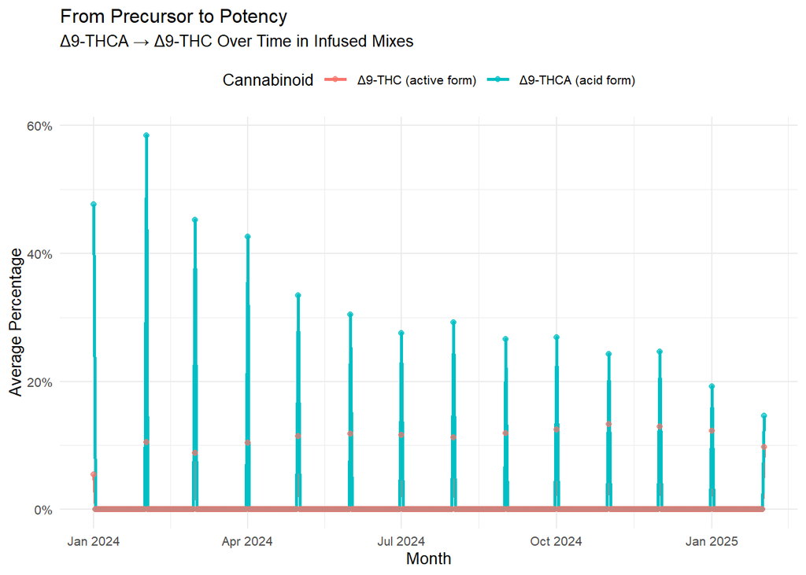

```r
# Filter for Infused Mixes
infused_data <- lab_data %>%
  filter(inventory_type_sub_category == "Infused Mixes") %>%
  mutate(month = floor_date(sale_date_month, "month"))

# Summarise average THCA and THC by month
infused_trends <- infused_data %>%
  group_by(month) %>%
  summarise(
    avg_thca = mean(potency_d9thca_perc_avg, na.rm = TRUE),
    avg_thc  = mean(potency_d9thc_perc_avg, na.rm = TRUE),
    .groups = "drop"
  ) %>%
  filter(!is.na(avg_thca) & !is.na(avg_thc) & !(avg_thca == 0 & avg_thc == 0)) %>%
  as_tsibble(index = month) %>%
  fill_gaps(avg_thca = 0, avg_thc = 0)

# Convert to long format for ggplot
infused_long <- infused_trends %>%
  pivot_longer(cols = c(avg_thca, avg_thc),
               names_to = "cannabinoid",
               values_to = "percentage") %>%
  mutate(cannabinoid = recode(cannabinoid,
                              avg_thca = "Δ9-THCA (acid form)",
                              avg_thc  = "Δ9-THC (active form)"))

# Plot side-by-side
ggplot(infused_long, aes(x = month, y = percentage, color = cannabinoid)) +
  geom_line(linewidth = 1) +
  geom_point(alpha = 0.7) +
  scale_y_continuous(labels = label_percent(scale = 1)) +
  labs(
    title = "From Precursor to Poten️cy",
    subtitle = "Δ9-THCA → Δ9-THC Over Time in Infused Mixes",
    x = "Month",
    y = "Average Percentage",
    color = "Cannabinoid"
  ) +
  theme_minimal(base_size = 10) +
  theme(legend.position = "top")
```

From Acid to Active: THCA to THC Trends in Infused Mixes (Monthly Averages)

[figure not shown]

Product shelf life: Over time, cannabis products sitting in labs, warehouses, or shelves may degrade or lose potency, especially THCA converting to other forms or degrading entirely.

Seasonal manufacturing patterns: Early months (e.g., Jan–Apr) likely reflect fresh batches, post-holiday surges, or early-year restocking. Later in the year, you might see smaller or older inventory tested.

Infused Mixes as a category can have lower cannabinoid consistency due to ingredient blends or inconsistent lab homogenization. If more low-THC batches were tested later in the year, average values drop.

Testing or reporting changes: Different labs, changing methods, or shifts in compliance priorities might influence reported averages.

Increased CBD or alternative focus: Some brands shift formulations throughout the year toward less psychoactive content — especially in the edible space.

Let’s repeat for the CBD chemistry, focusing on:

- CBDA (Cannabidiolic acid – the precursor)
- CBD (Cannabidiol – the neutral, active form)

We’ll:

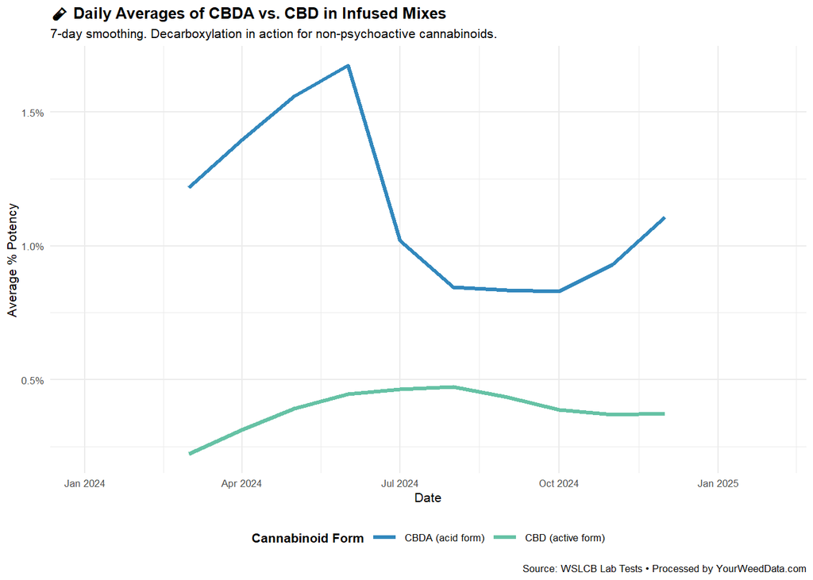

What We’ve Accomplished:

- Built precursor-product summaries (e.g., CBGA → THCA → THC → CBN)

Built a clean, repeatable pipeline for cannabinoid chemistry EDA.

Created visuals with real-world use cases that are useful to our clients✅